# R w QGIS

III Spotkanie Użytkowników QGIS

Author

Adrian Nowacki

Published

June 26, 2024

[figure not shown]

Ze względu na elastyczność oraz bogactwo dostępnych bibliotek, wykorzystanie języka R ma liczne zastosowania w statystyce, przetwarzaniu danych przestrzennych oraz ich zaawansowanej wizualizacji. Połączenie możliwości R z interfejsem QGIS może wpłynąć na znacznie szybsze i wygodniejsze przetwarzanie danych, a także pozwoli na wykorzystanie funkcji, które nie występują w podstawowej wersji oprogramowania QGIS.

## 1. Konfiguracja R w QGIS

1. Instalacja R (dla własnego użytku): https://cran.r-project.org/
2. Instalacja wtyczki *“Processing R Provider”* w *QGIS*

Na tym etapie w zakładce *Algorytmy Processingu -> Opcje -> Dostawcy* *algorytmów* powinniśmy mieć dołączony panel dla języka R, którego folder został automatycznie wykryty i podłączony. Jeśli folder się nie zgadza, należy go zmienić na poprawny – wybieramy miejsce, w którym zainstalowano R.

3. W przypadku wersji systemu 64-bit należy zaznaczyć opcję *“Use 64-bit version”* – jeśli posiadamy wersję 32-bit, okno to należy zostawić puste.
4. Warto zapamiętać, aby w celu instalacji pakietów najlepiej nie korzystać z R dostępnego w QGIS, lecz instalować je bezpośrednio w języku R, np. w RStudio. W tym celu należy w tym samym panelu zmienić ścieżkę instalowanych pakietów z folderu QGISa na folder R. Domyślną ścieżkę `C:\Users\x\AppData\Roaming\QGIS\QGIS3\profiles\default\processing\rlibs` należy zmienić na `C:\Users\x\AppData\Local\R\win-library\4.4` – ścieżka ta może być inna w różnych systemach operacyjnych i zależy od nazwy użytkownika oraz wersji języka R – w przypadku wersji poniżej 4.2, ścieżka ta będzie pod adresem `C:\Users\x\Documents\R\win-library\4.1`.

[figure not shown]

Po wykonaniu powyższych kroków należy zrestartować QGISa lub włączyć i wyłączyć używany profil użytkownika. W algorytmach processingu pojawia się wówczas ikona umożliwiająca korzystanie z języka R.

Istnieje również możliwość odwrotnej konfiguracji – wykorzystania algorytmów QGIS w języku R, przy pomocy takich pakietów jak qgisprocess lub nieutrzymywanych już [RQGIS3 i RQGIS](https://github.com/r-spatial/RQGIS3).

## 2. Instalacja dodatkowych algorytmów

Po konfiguracji mamy do dyspozycji pięć przykładowych skryptów:

- **“Expressions”** – umożliwia zapisanie wyrażeń z konsoli do pliku,
- **“Min_Max”** – wskazuje minimalną i maksymalną wartość kolumny wybranej warstwy wektorowej
- **“Scatterplot”** – tworzy wykres rozrzutu dla dwóch wybranych kolumn
- **“test_sf”** – uruchomiony za pierwszym razem instaluje podstawowe pakiety i zwraca warstwę jako obiekt *sf* (kopię warstwy wejściowej)
- **“test_sp”** – uruchomiony za pierwszym razem instaluje podstawowe pakiety i zwraca warstwę jako obiekt *sp* (starszą wersję *sf*)

Aby zainstalować dodatkowe algorytmy, które publicznie zostały dołączone do kolekcji QGIS, należy:

1. Zainstalować wtyczkę *“QGIS Resource Sharing”*
2. Włączyć wtyczkę i zainstalować kolekcję skryptów R (“*QGIS R script collection*”), w ramach której w algorytmach processingu zostanie dodanych 60 dodatkowych skryptów.

## 3. Struktura skryptów

Tworzenie skryptu opiera się na dwóch głównych etapach:

1. Instalacji wymaganych pakietów stricte w języku R za pomocą komendy `install.packages(c("sf", "terra", ggplot2"))`
2. Wskazaniu atrybutów algorytmu, które będą się wyświetlać w interfejsie algorytmu processingu: typu danych wejściowych oraz ich liczby, stałych parametrów użytych w kodzie (np. bufor z domyślną wartością 10 metrów), a także typu danych wynikowych

Etap ten definiuje wygląd algorytmu processingu, który zależy od liczby i typów użytych atrybutów, poprzez użycie prostego, podwójnego hashtaga *##* oraz *=*, gdzie po lewej stronie wskazujemy nazwę, jaka będzie wyświetlana w algorytmie, a po prawej – element, który pod daną nazwą będzie się wyświetlał.

2. Napisaniu kodu wykonującego analizę, wizualizującego dane w formie wykresu lub mapy lub zwracającego wynik w postaci tekstu, tabeli lub warstwy rastrowej/wektorowej.

Poniżej przedstawiono przykładowy kod obejmujący prostą operację przestrzenną oraz poszczególne etapy jej tworzenia. Skrypt wykonuje bufor dookoła wskazanej warstwy według wskazanej odległości oraz mapę prezentującą wszystkie zmienne obiektu.

```r
##Skrypty=group
##Layer=vector
##Output=output vector
##Size=number 1000
##showplots

library(sf)
buffer = st_buffer(Layer, Size)
Output=buffer
plot(Output)
```

Na skrypt może składać się:

- Określenie grupy algorytmów, w którym będzie znajdować się skrypt

```r
##Skrypty=group (Nazwa wyświetlana=zdefiniowany element)
```

- Zdefiniowanie typu oraz liczby danych wejściowych (w zależności od potrzeby może to być warstwa wektorowa, rastrowa, tabela, kolumna, numer, itd.)

```r
##Layer=vector
```

- Zdefiniowanie danych wyjściowych (warstwa wektorowa, rastrowa, tabela, wykres/mapa).

```r
##Output=output vector
```

Jeśli chcemy, aby wynikiem końcowym był tekst lub aby wynik został automatycznie wyświetlony be zapisania do pliku, należy pominąć ten element i umieścić “>” przed poleceniem, które chcemy wyświetlić.

- Zdefiniowanie potencjalnych kolumn wybranej warstwy wektorowej lub innych parametrów

```r
##Column 1=Field Layer
##Column 2=Field Layer

##Size=10
```

- Zdefiniowanie chęci wyświetlenia wykresu

```r
##showplots
```

- Wczytanie potrzebnych do analizy pakietów

```r
library(sf)
```

- Napisanie odpowiedniego kodu

```r
buffer = st_buffer(Layer, Size)
Output=buffer
```

Szczegóły dotyczące parametrów możliwych do zdefiniowania w kodzie jest bardzo dużo, dlatego warto zapoznać się ze wszystkimi możliwościami dostępnymi w dokumentacji: [QGIS R script syntax](https://docs.qgis.org/3.34/en/docs/user_manual/appendices/qgis_r_syntax.html).

## 4. Tworzenie skryptów

Po zaznajomieniu się ze strukturą skryptów R w QGIS, możliwym jest tworzenie skryptów mających na celu wizualizację, wykonanie analizy, obliczenie pewnych statystyk lub automatyzację pracy. Poniżej znajdują się wybrane skrypty, które prezentują poszczególne możliwości tworzenia takich skryptów:

##### 1. Obliczenie korelacji wybranych zmiennych:

```r
##Skrypty=group
##Layer=vector
##Column1=Field Layer
##Column2=Field Layer

corr=cor(Layer[[Column1]], Layer[[Column2]])
>corr
```

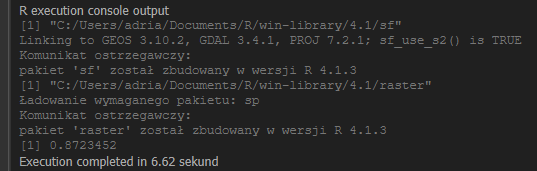

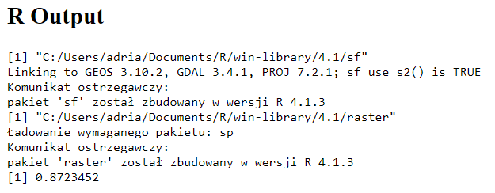

- Zaprezentowanie wyników w formie wykresu rozrzutu:

```r
##Skrypty=group
##Layer=vector
##output=output file
##Column1=Field Layer
##Column2=Field Layer

library(ggplot2)

png(filename=output, width=800, height=800)

ggplot(Layer, aes(x = !!sym(Column1), y = !!sym(Column2))) +
  geom_point(size = 5, color = "#222222") +  # Zwiększenie rozmiaru punktów
  labs(
    x = Column1,
    y = Column2
  ) +
  theme_minimal() +
  theme(
    text = element_text(size = 20),  # Zwiększenie rozmiaru czcionki ogólnie
    axis.title = element_text(size = 20),  # Zwiększenie czcionki tytułów osi
    plot.title = element_text(size = 24),  # Zwiększenie czcionki tytułu wykresu
    legend.text = element_text(size = 24),  # Zwiększenie czcionki w legendzie
    legend.title = element_text(size = 28)  # Zwiększenie czcionki tytułu legendy
  )
dev.off()
```

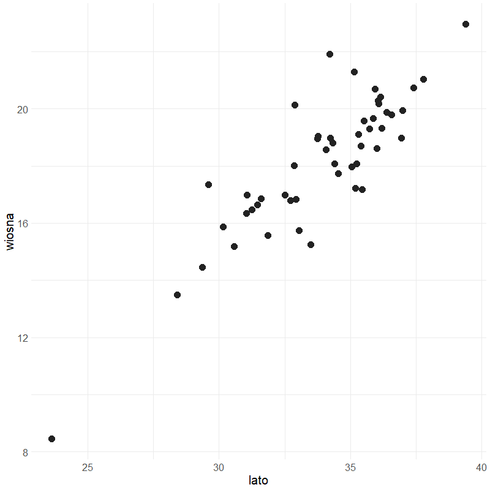

- Zaprezentowanie wyników w formie mapy:

```r
##Skrypty=group
##Layer=vector point
##Layer2=vector polygon
##Field=Field Layer
##showplots
##output=output file

library(tmap)
tmap_mode = "plot"

png(filename=output, width=1000, height=1000)
tm_shape(Layer2) +
    tm_borders(col="#222222", lwd=3) +
tm_shape(Layer) +
  tm_dots(col = Field, size = 4) +
tm_layout(
            title.size = 3,
            legend.text.size = 2,
            legend.title.size = 2.5
        )

dev.off()
```

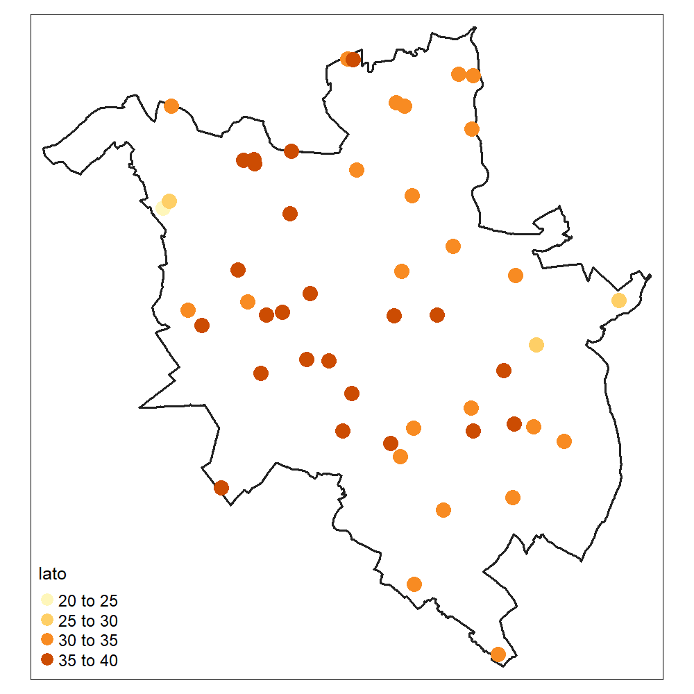

##### 2. Statystyki opisowe dla wybranej kolumny z warstwy:

```r
##Skrypty=group
##Layer=vector
##Field=Field Layer
##Stat=Output table

statistics <- data.frame(
    suma = sum(Layer[[Field]]),
    liczba = length(Layer[[Field]]),
    min = min(Layer[[Field]]),
    max = max(Layer[[Field]]),
    zakres = max(Layer[[Field]])-min(Layer[[Field]]),
    srednia = mean(Layer[[Field]]),
    mediana = median(Layer[[Field]]),
    odchylenie_std = sd(Layer[[Field]])
)
Stat<-statistics
```

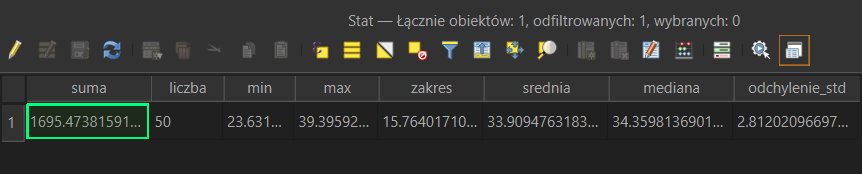

- Statystyki opisowe dla wybranej kolumny z wielu wybranych warstw:

```r
##Skrypty=group
##Layers=multiple vector
##Field=string
##Stat=Output table

statistics_df <- data.frame(
    Warstwa = character(),
    Suma = numeric(),
    Liczba = numeric(),
    Min = numeric(),
    Max = numeric(),
    Zakres = numeric(),
    Srednia = numeric(),
    Mediana = numeric(),
    Odchylenie_Std = numeric(),
    stringsAsFactors = FALSE
)

for (i in seq_along(Layers)) {
    layer <- Layers[[i]]

    sum_stat <- sum(layer[[Field]], na.rm = TRUE)
    count_stat <- length(layer[[Field]])
    min_stat <- min(layer[[Field]], na.rm = TRUE)
    max_stat <- max(layer[[Field]], na.rm = TRUE)
    range_stat <- max(layer[[Field]], na.rm = TRUE) - min(layer[[Field]], na.rm = TRUE)
    mean_stat <- mean(layer[[Field]], na.rm = TRUE)
    median_stat <- median(layer[[Field]], na.rm = TRUE)
    sd_stat <- sd(layer[[Field]], na.rm = TRUE)

    statistics_df <- rbind(statistics_df, data.frame(
        Warstwa = i,
        Suma = sum_stat,
        Liczba = count_stat,
        Min = min_stat,
        Max = max_stat,
        Zakres = range_stat,
        Srednia = mean_stat,
        Mediana = median_stat,
        Odchylenie_Std = sd_stat,
        stringsAsFactors = FALSE
    ))
}

Stat <- statistics_df
```

##### 3. Przykładowa analiza – obszary gminy dostępne pod zabudowę + przypisanie informacji o działkach:

```r
##Skrypty=group
##points=vector point
##polygon=vector polygon
##size=number 500

##column_1= Field polygon

##additional_layer=optional vector
##column_a= optional Field additional_layer

##bufor=output vector
##output_points=output vector
##path_map=output file



library(sf)

# TURBINY
# utworzenie buforu, agregacja buforów oraz zmiana warstwy na obiekt przestrzenny
bufor_700 <- st_buffer(points, dist = size)
bufor_700 <- st_union(bufor_700)
bufor_700 <- st_as_sf(bufor_700)

# obliczenie powierzchni buforu jako nowa kolumna
polygon <- st_as_sf(polygon)
bufor_700 <- st_intersection(bufor_700, polygon)
bufor_700$powierzchnia <- st_area(bufor_700)

# obliczenie powierzchni gminy oraz udziału procentowego obszarów dostepnych i niedostępnych pod zabudwę
pow_gminy <- st_area(polygon)
bufor_700$zajety_proc <- round((bufor_700$powierzchnia / pow_gminy) * 100, 3)
bufor_700$pod_zabudowe_proc <- round(100 - as.numeric(bufor_700$zajety_proc), 3)
bufor <- bufor_700

# dołączenie kolumn z warstwy gmin do turbnin
points <- st_join(points, polygon[, c(column_1)])




# DZIALKI
# dołączenie kolumn z innych warstw do turbnin
output_points <- st_join(points, additional_layer[, c(column_a)])
```

- wizualizacja wyników w postaci mapy przy pomocy pakietu *tmap*

```r
##path_map=output file

png(filename=path_map, width=1400, height=1400)

tm_shape(polygon) +
      tm_polygons(col = "#487575", lwd = 3) +
tm_shape(bufor_700) +
      tm_polygons(col = "#a0c5c5", lwd = 3) +
tm_shape(output_points) +
      tm_symbols(col = "WYSOKOSC", border.col = "#222222", shape=21, size=5) +
      tm_layout(
                title = "Lokalizacja oraz wysokosc turbin wiatrowych w gminie Margonin",
                title.size = 3,
                legend.text.size = 2,
                legend.title.size = 2.5
                )  +
tm_add_legend(
  type = "fill",
  labels = c("Obszary pod zabudowe", "Obszary wykluczone"),
  col = c("#487575", "#a0c5c5")
)

dev.off()
```

[figure not shown]

- wizualizacja wyników w postaci mapy przy pomocy pakietu *ggplot2*

```r
##path_map=output file

library(ggplot2)

png(filename=path_map, width=1400, height=1400)

ggplot() +
  geom_sf(data = polygon, aes(), fill = "#487575", color = "#222222") +
  geom_sf(data = bufor_700, aes(), fill = "#a0c5c5", color = "#222222") +
  geom_sf(data = output_points, aes(fill = WYSOKOSC), size = 7, shape = 21) +
scale_fill_gradient(low = "#FFFFCC", high = "#FF6600", name = "WYSOKOSC") +
  ggtitle("Wysokosc turbin wiatrowych w gminie Margonin") +
  theme(
    plot.title = element_text(size = 36),
    legend.text = element_text(size = 26),
    legend.title = element_text(size = 30),
    legend.key.height = unit(2, "cm")
  )

dev.off()
```

[figure not shown]

## 5. Struktura opisów

Każdy utworzony algorytm może mieć dodany opis – główną użyteczność algorytmu, informacje o parametrach, a także numer wersji i informacje o autorze. Tworzenie opisów nie jest automatycznie wspomagane przez processing algorytmów, więc plik z takim opisem należy utworzyć ręcznie przez dowolny edytor tekstu i zapis pliku do rozszerzenia .rsx.help (taki sam co w przypadku skryptów, jednak z dodatkiem .help). Struktura opisu zawiera się w słowniku `{}` i wygląda następująco:

- główny opis algorytmu:

```r
  "ALG_DESC": "Algorytm wykonuje dwa kroki: 1. Tworzy bufor warstwy punktowej (np. turbin wiatrowych), a następnie oblicza jego powierzchnię i udział procentowy w innym poligonie (np. gminie) 2. Tworzy kopię warstwy punktowej (potencjalnych turbin), przypisując informacje z innych warstw (np. numery działek)"
```

- informacje o autorze oraz kontakt:

```r
  "ALG_CREATOR": "Adrian Nowacki, adriannowacki007@gmail.com"
```

- opcjonalne informacje o pomocniczym autorze:

```r
  "ALG_HELP_CREATOR": "Imię Nazwisko, adres e-mail"
```

- informacja o wersji algorytmu:

```r
  "ALG_VERSION": "1.0.0"
```

- opis poszczególnych algorytmów, według ich nazw w kodzie źródłowym skryptu:

```r
  "points": "Warstwa punktowa, np. turbiny wiatrowe",
  "polygon": "Warstwa poligonowa, np. gmina",
  "size":"Rozmiar buforu w mterach",

  "column_1": "Kolumna z warstwy Polygon",
  "column_2": "Opcjonalna dodatkowa kolumna",

  "additional_layer": "Dodatkowa, opcjonalna warstwa, z której chcemy przypisać atrybuty do warstwy punktowej",
  "column_a":"Opcjonalna kolumna z dodatkowej warstwy"}
```

Plik .rsx.help powinien znajdować się w tym samym folderze, co plik skryptu .rsx. Należy pamiętać, aby całość była zawarta w słowniku `{}`, a każdy parametr był oddzielony przecinkiem. Zawartość końcowa powinna wyglądać następująco:

```r
{"ALG_DESC": "Algorytm wykonuje dwa kroki: 1. Tworzy bufor warstwy punktowej (np. turbin wiatrowych), a następnie oblicza jego powierzchnię i udział procentowy w innym poligonie (np. gminie) 2. Tworzy kopię warstwy punktowej (potencjalnych turbin), przypisując informacje z innych warstw (np. numery działek)",
"ALG_CREATOR": "Adrian Nowacki, adriannowacki007@gmail.com",
"ALG_VERSION": "1.0.0",

"points": "Warstwa punktowa, np. turbiny wiatrowe",
"polygon": "Warstwa poligonowa, np. gmina",
"size":"Rozmiar buforu w mterach",

"column_1": "Kolumna z warstwy Polygon",
"column_2": "Opcjonalna dodatkowa kolumna",

"additional_layer": "Dodatkowa, opcjonalna warstwa, z której chcemy przypisać atrybuty do warstwy punktowej",
"column_a":"Opcjonalna kolumna z dodatkowej warstwy"}
```

[figure not shown]